# “DeepMAPS-Guided matched scRNA-seq and scATAC_seq analyses tutorial”

Xiaoying Wang

2022/1/19

## Read matched scRNA and scATAC data and quality control

For this tutorial, we will be analyzing the dataset of Fresh Frozen Lymph Node with B-cell Lymphoma (14k sorted nuclei) freely available from 10X Genomics. 14,566 single cells were sequenced on the Illumina NextSeq 500. The raw data can be found [here](https://www.10xgenomics.com/resources/datasets/fresh-frozen-lymph-node-with-b-cell-lymphoma-14-k-sorted-nuclei-1-standard-2-0-0). We start by reading the data. The ReadData function reads the .h5 file from given h5Path and removes the peak/gene if the value in the gene/peak with more than min_cell cell is equal to zero, returning a Seurat object. The Seurat object contains two count matrices stored in lymph_obj[[‘RNA’]]@counts and lymph_obj[[‘ATAC’]]@counts. DeepMAPS will automatically remove outlier cells. We will identify if a cell is an outlier based on the scRNA count matrix, scATAC count matrix, and mitochondrial genes. And the outlier cells will be removed in the Seurat object.

```r
## Load function
source("/home/wan268/hgt/RNA_ATAC/scRNA_scATAC1.r")
# set python environment
Sys.setenv(RETICULATE_PYTHON = "/home/wan268/.conda/envs/hgt1/bin/python")
use_python("/home/wan268/.conda/envs/hgt1/bin/python")
py_config()
```

```
## python:         /home/wan268/.conda/envs/hgt1/bin/python
## libpython:      /home/wan268/.conda/envs/hgt1/lib/libpython3.8.so
## pythonhome:     /home/wan268/.conda/envs/hgt1:/home/wan268/.conda/envs/hgt1
## version:        3.8.5 (default, Sep  4 2020, 07:30:14)  [GCC 7.3.0]
## numpy:          /home/wan268/.conda/envs/hgt1/lib/python3.8/site-packages/numpy
## numpy_version:  1.20.2
##
## NOTE: Python version was forced by RETICULATE_PYTHON
```

```r
####
## Read matched scRNA and scATAC data and quality control
#input:
#  h5Path: the path of h5 file
#  min_cell: the peak / gene will be removed if the value in the gene / peak with more than min_cell cell is equal to zero, default = 0.1
#output:
#  a seurat object
lymph_obj <- ReadData(h5Path = "/home/wan268/hgt/RNA_ATAC/lymph_node_lymphoma_14k_filtered_feature_bc_matrix.h5", data_type = "scRNA_scATAC", min_cell = 0.001, dataFormat = "h5")
lymph_obj
```

```
## An object of class Seurat
## 91530 features across 10438 samples within 2 assays
## Active assay: RNA (21477 features, 0 variable features)
##  1 other assay present: ATAC
```

## Calculate peak-gene regulatory potential matrix

After removing outlier cells from the dataset, the next step is to calculate the regulatory score from the scATAC count matrix stored in lymph_obj@assays$ATAC@counts’ based on the package MAESTRO. The reference genome default as CRCh38. If the mouse data you have, the species can be set as GRCm38. After calculating the gene active score step, the ATAC_gene_peak matrix will be returned. All peaks in scATAC data will be calculated a regulatory score with genes provided by the reference genome. Some solutions of install package in R and python have been summarized in README.

```r
##' Calculate peak-gene regulatory potential matrix
# input:
#  peak_count_matrix: a peak_count matrix from scATAC-seq with peak * cell which return from filterCell function
#  organism: species type GRCh38 / GRCm38, default = GRCh38
#  pythonPath: the path of python with MAESTRO package
# output:
#  a gene * peak matrix, the elements represent the regulatory potential for peak to gene

ATAC_gene_peak <- CalGenePeakScore(peak_count_matrix = lymph_obj@assays$ATAC@counts,organism = "GRCh38")
```

## Calculate gene active score (integeation)

```r
## Calculate gene active score matrix
#input:
#  ATAC_gene_peak: a matrix with gene * peak which return from CalGenePeakScore fucntion
#  obj: a seurat object after data preprocessing which return from filterCell function
#  method: the method to integrate scRNA-seq and scATAC-seq velo (velocity) / WNN (weighted nearest neighbor)
#  veloPath: if use velocity method, the veloPath should be provided
#  return.weight: if return.weight = T, return modality integrated weight, else return GAS
#output:
#  GAS matrix with gene * peak, the elements represent the gene activity score in each cell
#  obj: a seurat object with obj[['ATAC_active']] a gene * peak matrix, the elements represent the regulatory potential for peak to gene

velo <-"/home/wan268/hgt/RNA_ATAC/velo/lymph_node_lymphoma_14k_filtered_feature_bc_matrix.csv"
GAS_obj <- calculate_GAS_v1(ATAC_gene_peak = ATAC_gene_peak, obj = lymph_obj, method = "velo", veloPath = velo)
GAS <- GAS_obj[[1]]
lymph_obj <- GAS_obj[[2]]
```

## Perform heterogeneous graph transformer (HGT) model on GAS matrix

Next, we apply HGT, a deep learning framework, to the GAS matrix. Four folders (cell, gene, model, att) should be built in the result_dir path. For scRNA_scATAC data, the data_type’ should be set “scRNA_scATAC,” and the joint embedding of gene and cell from HGT will be saved in the result_dir path/gene(/cell). The attention of the gene to the cell is stored in the /result_dir/att. The trained model is stored in the /result_dir/model. All the results are stored in the R variable as a list HGT_result. The parameters in deep learning are set as default. All the results are stored in the R variable as a list HGT_result. The parameters in deep learning are set as default. The lr, n_hid, n_heads,epoch can be changed by users. The introduction of each parameter in deep learning are provide in Tutorial_install_package.

```r
# required package -- reticulate
# input:
#  GAS: the spliced and normalized matrix obtained from CLR function
#  result_dir: The address for storing the models and optimization results(Type:str)
#  epoch:(Type:int)
#  lr: learning rate(Type:float)
#  n_hid: Number of hidden dimension(Type:int)
#  n_heads: Number of attention head(Type:int)
#  cuda: 0 use GPU0 else cpu(Type:int)
#  data_type: 'CITE', 'RNA_ATAC', or 'multiple RNA'
#  envPath: The address for environment to use if use.env is TRUE(Type:str)
# output:
#  HGT_result: a list containing requried results of HGT model as follows:
#  parameters: given parameters from user --epoch, lr, n_hid, n_heads, cuda
#  cell_hgt_matrix: cell embedding matrix
#  feature_hgt_matrix : gene embedding matrix and protein embedding matrix when data_type is 'CITE';
#  attention: attention meassage for features and cells
#  data_type: 'CITE', 'RNA_ATAC', or 'multiple RNA'
#  result_dir: The address for storing the models and optimization results
#  GAS: the spliced and normalized matrix obtained from CLR function

HGT_result <- run_HGT(GAS = as.matrix(GAS),result_dir='/home/wan268/hgt/RNA_ATAC/', data_type='scRNA_scATAC', envPath=NULL, lr=0.2, epoch=30, n_hid=128, n_heads=16)
```

## Cluster the cells

After running the HGT model, DeepMAPS applies Louvain, a graph-based model, to cluster cells based on the cell feature reduction matrix, which returns from the HGT model (stored in HGT_result[[‘cell_hgt_matrix’]]).

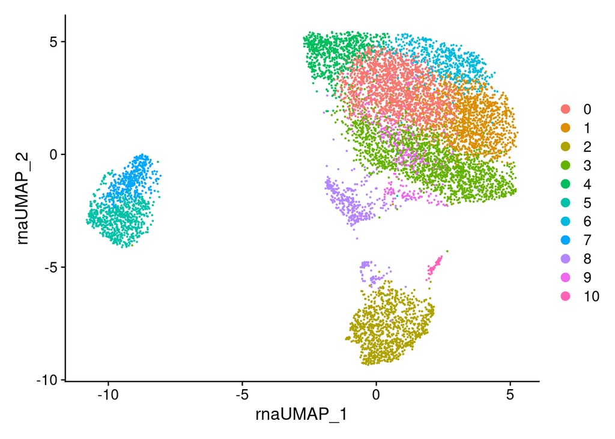

```r
cell_hgt_matrix <- HGT_result[['cell_hgt_matrix']]
rownames(cell_hgt_matrix) <- colnames(GAS)

lymph_obj <- lymph_obj[, colnames(GAS)]
cell_hgt_matrix <- cell_hgt_matrix[colnames(GAS),]

HGT_embedding <-
  CreateDimReducObject(embeddings = cell_hgt_matrix,
                       key = "HGT_",
                       assay = "RNA")
lymph_obj@reductions[['HGT']] <- HGT_embedding
lymph_obj <-
  FindVariableFeatures(lymph_obj, selection.method = "vst", nfeatures = 2000)
lymph_obj <- ScaleData(lymph_obj, features = VariableFeatures(lymph_obj))
lymph_obj <-
  RunUMAP(
    lymph_obj,
    reduction = 'HGT',
    dims = 1:ncol(cell_hgt_matrix),
    reduction.name = "umap.rna",
    reduction.key = "rnaUMAP_"
  )
lymph_obj <-
  FindNeighbors(lymph_obj,
                reduction = "HGT",
                dims = 1:ncol(cell_hgt_matrix))
lymph_obj <- FindClusters(lymph_obj, resolution = 1)

DefaultAssay(lymph_obj) <- "RNA"
DimPlot(lymph_obj, reduction = 'umap.rna')
```

## The FeaturePlot of marker genes

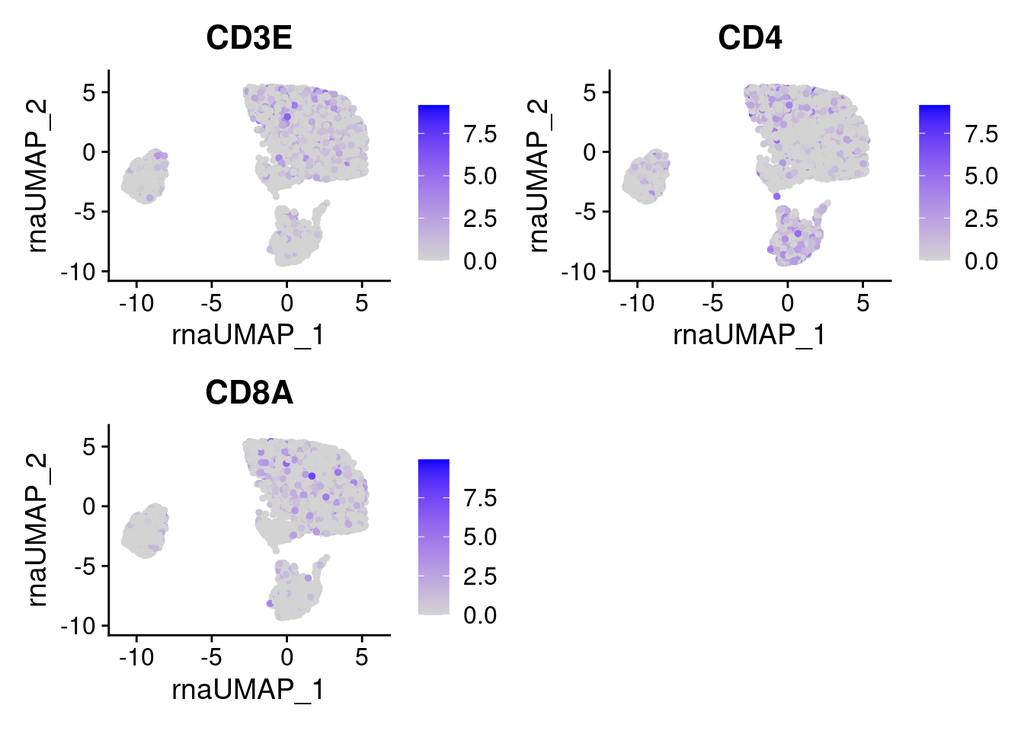

```r
GAS_assay <-
      CreateAssayObject(counts = GAS,
                        min.cells = 0)

lymph_obj[['GAS']] <- GAS_assay
genelist <- c('CD3E', 'CD4', 'CD8A')
DefaultAssay(lymph_obj) <- "GAS"
FeaturePlot(
  lymph_obj,
  features = genelist,

  #ncol = 3,
  keep.scale = NULL,
  pt.size = 1
)
```

## The coverage plot

Users should provide the fragments file and define the reference genome for this plot. The default assay in the Seurat object should be set as scATAC matrix.

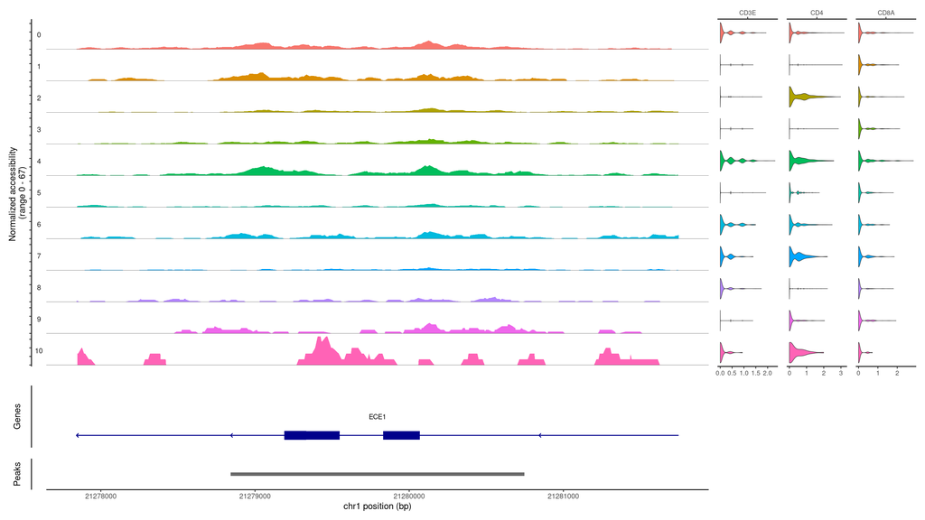

```r
DefaultAssay(lymph_obj) <- "ATAC"
anno <- qs::qread(paste0("/home/wan268/hgt/RNA_ATAC/", "hg38_annotations.qsave"))
Annotation(lymph_obj) <- anno
frag_path <-
  "/home/wan268/hgt/RNA_ATAC/lymph_node_lymphoma_14k_atac_fragments.tsv.gz"
fragments <- CreateFragmentObject(
  path = frag_path,
  cells = colnames(lymph_obj),
  validate.fragments = FALSE
)
fragments <-
  Fragments(lymph_obj) <- fragments

CoveragePlot(
          object = lymph_obj,
          features = c('CD3E', 'CD4', 'CD8A'),
          region = "chr1-21278842-21280747",
          extend.upstream = 1000,
          extend.downstream = 1000,
          expression.assay = "ATAC_active",
          expression.slot = "counts",
          ncol = 1
      )
```

## The Violin plot of marker genes

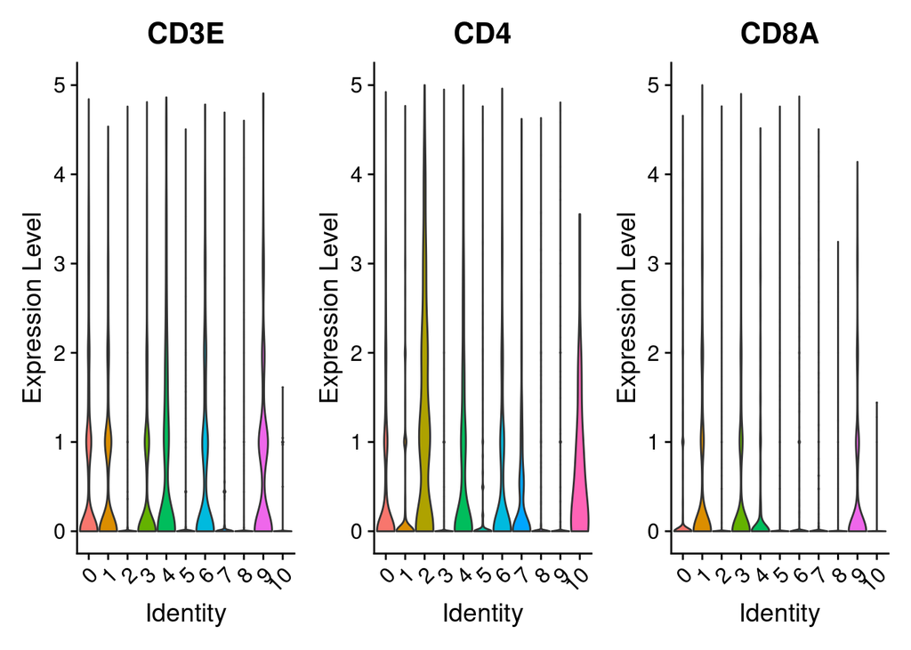

```r
genelist <- c('CD3E', 'CD4', 'CD8A')
VlnPlot(
  lymph_obj,
  features = genelist,
  assay = 'GAS',
  y.max = 5,
  #ncol = 3,
  pt.size = 0
)
```

## Cell type annotation and show UMAP

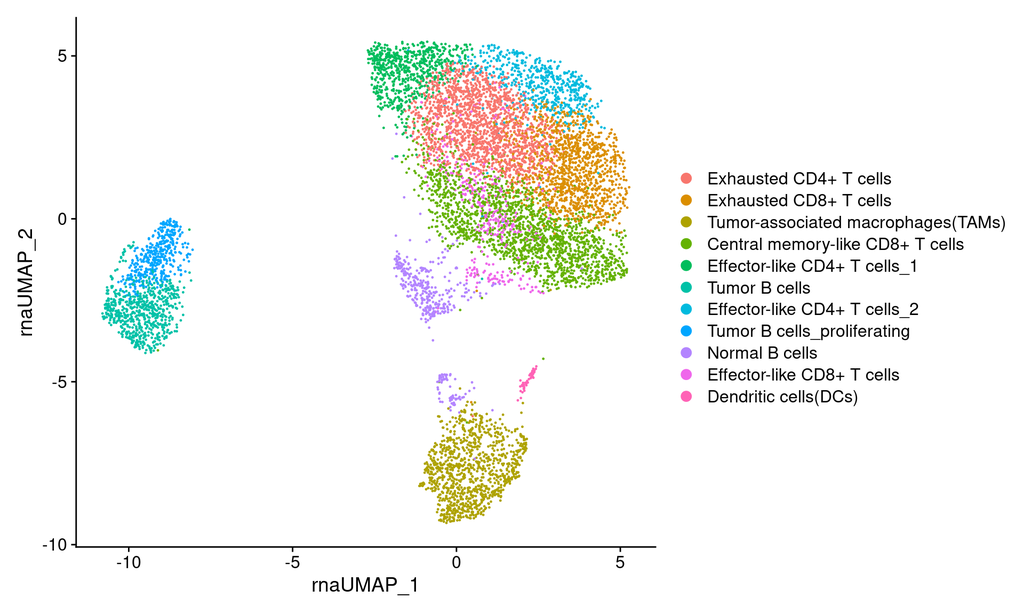

```r
# rename
new.cluster.ids <-
  c(
    'Exhausted CD4+ T cells',
    'Exhausted CD8+ T cells',
    'Tumor-associated macrophages(TAMs)',
    'Central memory-like CD8+ T cells',
    'Effector-like CD4+ T cells_1',
    'Tumor B cells',
    'Effector-like CD4+ T cells_2',
    'Tumor B cells_proliferating',
    'Normal B cells',
    'Effector-like CD8+ T cells',
    'Dendritic cells(DCs)'

  )
names(new.cluster.ids) <- levels(lymph_obj)
lymph_obj <- RenameIdents(lymph_obj, new.cluster.ids)
DimPlot(lymph_obj, reduction = 'umap.rna')
```

## Calculate cell cluster active gene modules and run LISA for TF infer.

To find the cell cluster biological meaningful gene module, the gene reduction matrix (stored in HGT_result[[‘feature_hgt_matrix’]]’ ), and attention value of gene to cell (stored in HGT_result[[‘attention’]]’ ), need to be provided, which also obtained from HGT model. Then the clustering result and cell type active biological gene module will be stored in co and graph.out variables. To infer TF by [LISA](https://github.com/liulab-dfci/lisa2), we write the biological gene module in the lisa_path’. The run_lisa.py code is here

```r
# CT active gene modules calculation
# input:
#  obj: a seurat object
#  GAS: a gene active matrix with gene * cell which return from calculate_GAS function
#  cell_hgt_matrix: cell-embedding matrix which otains from HGT function
#  att: attention matrix with gene-cell * head which obtain from HGT function
#output:
#  co (variable 1): a biological gene module. a list with name CT-i and active gene list in CT-i
co <- get_gene_module(obj = lymph_obj, GAS = GAS, att = HGT_result[['attention']],method = 'SFP' )

# gene module save
#input:
#  co: the active gene module from get_gene_module function
#  lisa_path: the path of active gene module to save
#result
#  write gene module to the lisa_path
lisa_path <- "/home/wan268/hgt/RNA_ATAC/lymph_14k_1/"
dir.create(lisa_path, showWarnings = F)
write_GM(co = co, lisa_path = lisa_path)
#run lisa.py in the LISA environment
system(
  paste0(
    "/home/wan268/.conda/envs/lisa/bin/python /scratch/deepmaps/code/run_lisa.py --path ",
    lisa_path,
    " --species ",
    "hg38"
  )
)
```

## Filter gene with no accessible peak in promoter

Next, consider the accessibility of the promoter region of each gene. The gene will be filtered if there is no accessible peak in the promoter. If the data belongs to human species, the species’ parameter is set to “hg38”. If the data belongs to mouse species, the species’ parameter is set to “mm10”. Then gene_peak_pro will be returned by the function AccPromoter()[[‘feature_hgt_matrix’]]’.

```r
# Filter gene with no accessible peak in promoter
# input:
#  lymph_obj: a seurat object which return from filterCell function
#  gene_peak: a matrix with gene * peak from scATAC-seq which return from filterCell function
#  GAS: the GAS matrix with gene * cell which return calculate_GAS function
#  species: hg38 / mm10
#output:
# a matrix with gene * peak. The gene with no accessible peak will be removed
gene_peak_pro <- AccPromoter(obj = lymph_obj, gene_peak = ATAC_gene_peak, GAS = GAS, species = 'hg38')
```

```
##  chr [1:11535] "LINC01128" "NOC2L" "KLHL17" "ISG15" "AGRN" "AGRN" ...
```

## Infer candicate cell type active regulons

We use TF binding site database from [JASPAR](http://expdata.cmmt.ubc.ca/JASPAR/downloads/UCSC_tracks/2020/) to infer candidate cell type active regulon and calculate binding affinity from TF to the peak.

```r
## infer ct active regulons
# input:
# GAS: the GAS matrix with gene * cell which return calculate_GAS function
# co: a list of bio network which reture from gene_ function
# gene_peak_pro: the matrix with gene * peak which return AccPromoter function
# species: human / mouse (human = "hg38", mouse = "mm10" )
# jaspar_path: if speices == human, the TF binding RData absolute path of hg38 should be provided,if speices == mouse, the TF binding RData absolute path of mm10 should be provided
# lisa_path: the co saved path
#output:
# BA_score a TF binding affinity matrix with TF * peak, the elements in the matrix is the binding power of TF to peak
# ct_regulon: candidate cell type active regulon
# TFinGAS: TRUE / FALSE, if number of the intersection of candidate TF from LISA and gene in GAS > 50 TFinGAS will be true, else it will be false
pre_regulon_res <- Calregulon(GAS = GAS, co = co, gene_peak_pro = gene_peak_pro, species = "hg38", jaspar_path = "/scratch/deepmaps/jaspar/", lisa_path = lisa_path)
BA_score <- pre_regulon_res[[1]]
ct_regulon_v1 <- pre_regulon_res[[2]]
TFinGAS<- pre_regulon_res[[3]]
```

## Combine same TF

Due to the JASPER database binding file having TF in the different regions of the peak, we combine the same TF.

```r
# combine same TF
#input:
# gene_peak_pro: a matrix with gene * peak. The gene with no accessible peak will be removed which return from AccPromoter function
# BA_score: a TF binding affinity matrix with TF * peak, the elements in the matrix is the binding power of TF to peak which returen from Calregulon function
#output:
# peak_TF: a matrix with peak * TF without repeat TF
peak_TF <- uni(gene_peak_pro = gene_peak_pro, BA_score = BA_score)
head(peak_TF[1:3,1:10])
```

```
##                    RUNX1 TFAP2A PAX5 NR2F1 E2F1 NFIL3 ELK1 FOXF2 FOXC1 GATA1
## chr1-180919-181688     0      0    0     0    0     0    0     0     0     0
## chr1-191320-191709     0      0    0     0    0     0    0     0     0     0
## chr1-629730-630167     0      0    0     0    0     0    0     0     0     0
```

## Calculate regulatory Intensive (RI) score in cell level and infer cell type active regulon

Next, we calculate the regulatory Intensive score of TF to gene.

```r
# Regulatory Intensive (RI) score in cell level
# input:
#  obj: a seurat object which return from filterCell function
#  ct_regulon: cell type active regulon
#  GAS: the GAS matrix with gene * cell which return calculate_GAS function
#  gene_peak_pro: the matrix with gene * peak which return from AccPromoter function
#  peak_TF: the matrix with peak * TF which return from uni function
#  graph.out: a factor variable. The predict cell cluster which return from get_gene_module function
#output:
#  RI_C: a regulatory intensive matrix with TF-gene pair * cell, the element means the intensity of TF to gene in each cell
graph.out <- as.factor(lymph_obj$seurat_clusters)
RI_C <- RI_cell(obj = lymph_obj, ct_regulon = ct_regulon_v1, GAS = GAS, gene_peak_pro = gene_peak_pro, peak_TF = peak_TF, graph.out = graph.out)
head(RI_C[1:3,1:10])
```

```
##            [,1] [,2] [,3] [,4] [,5] [,6] [,7] [,8] [,9] [,10]
## BCL6_ACTB     0    0    0    0    0    0    0    0    0     0
## BCL6_ACTG1    0    0    0    0    0    0    0    0    0     0
## BCL6_ACTN4    0    0    0    0    0    0    0    0    0     0
```

## Calculate regulon active score1 (RAS1)

Next, to analyze cell type-specific regulon, we define RAS1, which calculates regulon’s active score in different topologies with the same TF in different cell types.

```r
# input:
#  RI_C: a regulatory intensive matrix with TF-gene pair * cell, the element means the intensity of TF to gene in each cell
#  ct_regulon: cell type active regulon
#  graph.out: a factor variable. The cell cluster which return from get_gene_module function
#  TFinGAS: TRUE / FALSE, if number of the intersection of candidate TF from LISA and gene in GAS > 50 TFinGAS will be true, else it will be false which return from Calregulon function
#output:
#  RAS_CT: regulon active score in cell type level
#  RI_CT: regulatory intensive score in cell type level
#  ct-regulon: cell type active regulon
#  RAS_C1: a matrix regulon-CT * cell, regulatory active score in cell level
regulon_res <- calRAS(RI_C = RI_C, ct_regulon = ct_regulon_v1, graph.out = graph.out, TFinGAS = TFinGAS)
RAS_CT <- regulon_res[[1]]
RI_CT <- regulon_res[[2]]
ct_regulon <- regulon_res[[3]]
RAS_C1 <- regulon_res[[4]]
head(ct_regulon[1:3])
```

```
## $BCL6_ct0
##  [1] "ACTB"      "ACTN4"     "ADGRE5"    "AGAP1"     "AOAH"      "APOBEC3H"
##  [7] "APRT"      "ARID3A"    "ARID5A"    "ATXN1"     "ATXN7L1"   "BCL11B"
## [13] "CD38"      "CD44"      "CDK6"      "CELF2"     "CFL1"      "CXCR6"
## [19] "CYLD"      "CYTH4"     "EEF1A1"    "EVL"       "FYN"       "GAPDH"
## [25] "GPR132"    "HNRNPLL"   "HS3ST3B1"  "ID2"       "IL32"      "INPP4A"
## [31] "IRF1"      "ITGB2"     "KSR1"      "LAT"       "LCP2"      "LITAF"
## [37] "LRRFIP1"   "LSM4"      "MADD"      "MALAT1"    "MCTP2"     "MED13L"
## [43] "MMP25-AS1" "MYH9"      "MYO1F"     "NCALD"     "NLRC5"     "PACS2"
## [49] "PBX4"      "PCBP1-AS1" "STX10"     "TBC1D2B"   "THEMIS2"   "TNFRSF9"
## [55] "TNS3"      "TPGS1"     "TPM4"      "TPT1"      "TPT1-AS1"  "TSC22D4"
## [61] "UBAC1"     "UBASH3A"   "VAMP1"     "VPS37C"    "WBP2"      "WDR1"
## [67] "XRCC3"     "ZFP36L1"   "ZNF414"
##
## $IRF2_ct0
```

[output cut: 74 more lines]

## Calculate RAS2 same topology in a row

Next, to analyze cell type-specific regulon, we define RAS2, which calculates active regulon score in the same topology with the same TF in different cell types.

```r
##calculate RAS(2) same topology in a row
# calculate regulon active score in cell level / cell type level
# input:
#  ct_regulon: a matrix with gene * peak from scATAC-seq which return from get_gene_module function
#  graph.out: a factor variable. The predict cell cluster which return from get_gene_module function
#output:
#  RAS_C2: a matrix with regulon-CT * cell. Regulon active score in cell type level

RAS_C2 <- CalRAS2(ct_regulon, graph.out)
head(RAS_C2[1:3,1:10])
```

[output not shown]

## Calculate master TF

Next, we calculate TF/genes’ centrality score to define the master TF/gene in each cell type, and the network in each cell type is also provided, which is displayed as an adjacent matrix.

```r
##calculate master TF
#find master TF and master gene, build a cell type gene regulatory network
#input:
# ct_regulon: cell type active regulon
# RI_CT: regulatory intensive score in cell type level which return from calRAS funciton
#output:
# TF_cen: TF centrality score in each CT
# gene_cen: gene centrality score in each CT
# network: adjcent matrix in a CT
masterTF <- masterFac(ct_regulon = ct_regulon, RI_CT = RI_CT)
TF_cen <- masterTF[[1]]
gene_cen <- masterTF[[2]]
network <- masterTF[[3]]
```

[output not shown]

## Calculate cel type specific

To find cell type specific regulon, we calculate the differential score of each ct_regulon[[‘feature_hgt_matrix’]]’ in the same topology (RAS2).

```r
##calculate DR
#infer cell type specific regulon
#input:
#  RAS_C2: a matrix with regulon-CT * cell. Regulon active score in cell type level
#  graph.out: a factor variable. The predict cell cluster which return from get_gene_module function
#  only.pos: only print positive regulons
#  lfcThre: logFoldchange threshold, default = 0.25
#  pvalThres: pvalue threshold, default = 0.05
#output:
#  DR: differnent regulons.

DR <-
  calDR(
    RAS_C2,
    graph.out,
    only.pos = T,
    lfcThres = 0.25,
    pvalThres = 0.05
  )
DR[1:2]
```

```
##                   p_val avg_log2FC pct.1 pct.2     p_val_adj cluster  gene from
## SRF-ct0    8.530808e-05  0.2795953 0.282 0.250  1.035640e-01       0   SRF  ct0
## GATA4-ct2 1.482066e-130  0.4070078 0.715 0.408 1.799228e-127       2 GATA4  ct2
```